# Predicting How Effectively People Exercise

Adrien Seybert

12/19/2014

Introduction

The goal of this project is to develop a model predicting how effectively six participants exercised, based on nearly 20,000 observations of 160 variables. Class, the factor variable that ranks effectiveness from most to least serves as the regressor.

Summary

The top two most important predictors are pitch_forearm followed by yaw_belt. The predictor roll_belt showed a greater than .8 correlation with several other predictors so it was removed from the training set.

Developing the Model

1. Read in training and testing data.

```r
## Read In Training and Testing Data

training=read.csv("pml-training.csv",  stringsAsFactors=F, header=TRUE)
testing=read.csv("pml-testing.csv", stringsAsFactors=F, header=TRUE)
```

2. Clean up data in testing and training sets by removing variables with full columns of NAs and unnecessary ones such as name. I kept only numeric variables in testing and training sets, with the exception of classe, which was removed from the training set and reattached after cleanup)

```r
## Delete NAs from training set

newtrain=training[sapply(training, function(training) !any(is.na(training)))]

## Remove Unnecessary Variables

newtrain<-newtrain[, -c(1:7)]

## Remove NAs in testing set

newtest=testing[sapply(testing, function(testing) !any(is.na(testing)))]

##Retain Columns In Training Set That Are Numeric and Aren't NAs and subset out Classe variable to add later through cbind.

## Delete Classe Variable Column before subsetting out only numeric variables and deleting ones with NAs.

newtrain<-newtrain[,-86]

newtrain <- newtrain[sapply(newtrain, is.numeric)]
classe<-training[,160]
newertrain<-cbind(newtrain, classe)
```

2. Take a look at the non-NA predictors to eliminate variables that correlate with others.

```r
## Setting up correlation matrix
Correlation <- abs(cor(newertrain[,-53]))
diag(Correlation) <- 0
which(Correlation > 0.8,arr.ind=T)
```

```
##                  row col
## yaw_belt           3   1
## total_accel_belt   4   1
## accel_belt_y       9   1
## accel_belt_z      10   1
## accel_belt_x       8   2
## magnet_belt_x     11   2
## roll_belt          1   3
## roll_belt          1   4
## accel_belt_y       9   4
## accel_belt_z      10   4
## pitch_belt         2   8
## magnet_belt_x     11   8
## roll_belt          1   9
## total_accel_belt   4   9
## accel_belt_z      10   9
## roll_belt          1  10
## total_accel_belt   4  10
## accel_belt_y       9  10
## pitch_belt         2  11
## accel_belt_x       8  11
## gyros_arm_y       19  18
## gyros_arm_x       18  19
## magnet_arm_x      24  21
## accel_arm_x       21  24
## magnet_arm_z      26  25
## magnet_arm_y      25  26
## accel_dumbbell_x  34  28
## accel_dumbbell_z  36  29
## gyros_dumbbell_z  33  31
## gyros_forearm_z   46  31
## gyros_dumbbell_x  31  33
## gyros_forearm_z   46  33
## pitch_dumbbell    28  34
## yaw_dumbbell      29  36
## gyros_forearm_z   46  45
## gyros_dumbbell_x  31  46
## gyros_dumbbell_z  33  46
## gyros_forearm_y   45  46
```

Observation: It appears that the variable roll_belt has a high degree of correlation with yaw_belt, total_accel_belt, accel_belt_y, accel_belt_z. Might be a good idea to take it out.

```r
## Remove Roll_Belt From Training Set

newertrain=newertrain[,-1]
```

3. Pick 5000 random observations of nearly 20,000 from newertrain, which is cleaned training data, using 51 predictors.

```r
## Call up Caret Package

library(caret)
## Call up Kimisc Package to use sample.rows function to pick 5000 random observations. Set seed.

library(kimisc)
set.seed(1550)
newtrainsample<-sample.rows(newertrain,5000, replace=TRUE)
```

```r
controltrain <- trainControl(method = "cv", number = 3, allowParallel = TRUE)
```

5. Create the Random Forest model, using 1,000 trees with centered and scaled preprocessing

```r
## Create Model To Fit Random Row Data Using Random Forest Method, Setting Number of Trees at 1000.

trainfit <- train(classe~., data = newtrainsample, method="rf", preProc=c("center", "scale"), trControl = controltrain, prox=FALSE, ntree=1000)
```

6. Print out trainfit’s summary.

```r
cat("Trainfit's Summary", "\n")
```

```
## Trainfit's Summary
```

```r
print(trainfit)
```

```
## Random Forest
##
## 5000 samples
##   51 predictors
##    5 classes: 'A', 'B', 'C', 'D', 'E'
##
## Pre-processing: centered, scaled
## Resampling: Cross-Validated (3 fold)
##
## Summary of sample sizes: 3335, 3333, 3332
##
## Resampling results across tuning parameters:
##
##   mtry  Accuracy  Kappa   Accuracy SD  Kappa SD
##    2    0.9688    0.9603  0.005357     0.006805
##   26    0.9696    0.9614  0.007736     0.009819
##   51    0.9668    0.9578  0.006448     0.008178
##
## Accuracy was used to select the optimal model using  the largest value.
## The final value used for the model was mtry = 26.
```

7. Plot trainfit to get more information.

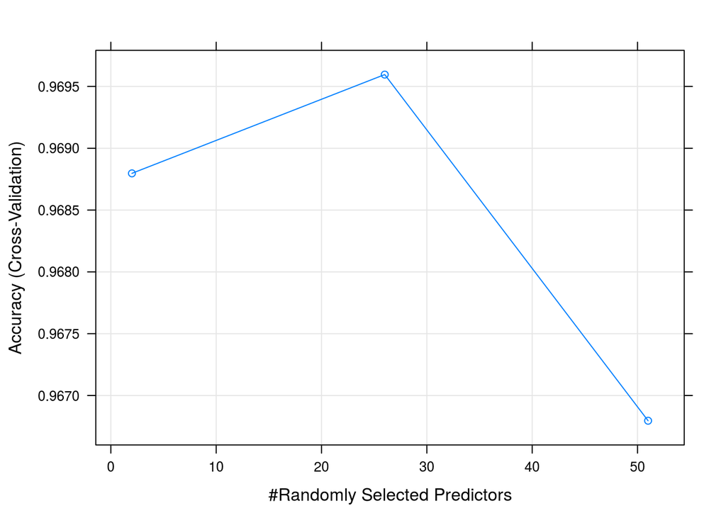

```r
## Plot Trainfit
plot(trainfit)
```

8. Rank variables by importance using VarImp and plot top ones vs. class.

```r
topvariables=varImp(trainfit)
print(topvariables)
```

```
## rf variable importance
##
##   only 20 most important variables shown (out of 51)
##
##                      Overall
## pitch_forearm          100.0
## yaw_belt                88.7
## magnet_dumbbell_z       70.3
## pitch_belt              63.9
## roll_forearm            55.2
## magnet_dumbbell_y       51.0
## accel_belt_z            40.6
## magnet_belt_z           32.5
## magnet_belt_y           32.1
## roll_dumbbell           32.1
## magnet_dumbbell_x       27.9
## accel_forearm_x         25.4
## accel_dumbbell_y        23.5
## gyros_belt_z            23.1
## accel_dumbbell_z        22.0
## magnet_forearm_z        19.1
## magnet_belt_x           17.1
## total_accel_dumbbell    16.1
## accel_dumbbell_x        15.5
## accel_forearm_z         15.2
```

The two top variables – pitch_forearm and yaw_belt have a -0.006 correlation, which shows that they have no linear relationship.

9. Plot densities of two top variables by classe

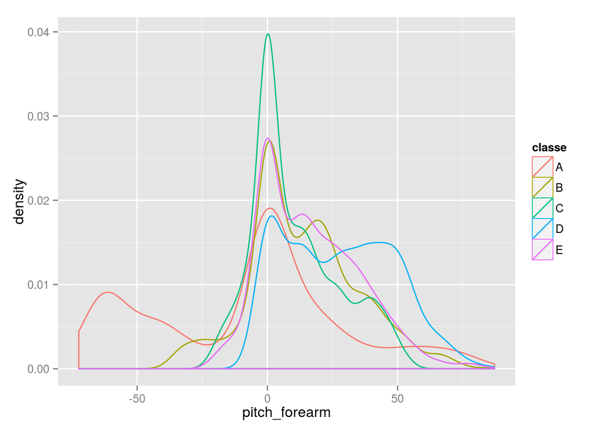

```r
## plot densities of top two variables.

qplot(pitch_forearm,colour=classe, data=newtrainsample, geom="density")
```

Class A, the most effective exercise style, hits its greatest height at 0 pitch_forearm. It’s nearly a normal distribution from -25 to 75. There’s a bump around -60 to half it’s greatest height.

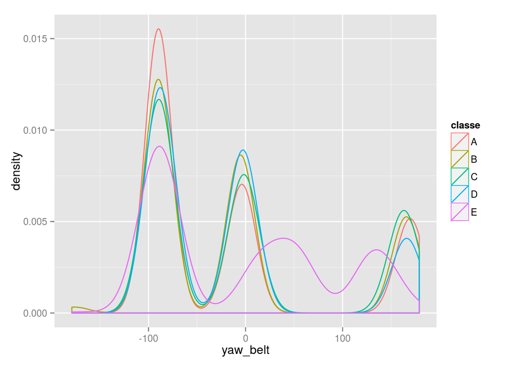

```r
qplot(yaw_belt,colour=classe,data=newtrainsample, geom="density")
```

10. Apply training model to testing data.

```r
## Running the prediction on the test data
pred <- predict(trainfit,newtest)
cat("The predictions for the 20 samples are", as.character(pred))
```

```
## The predictions for the 20 samples are B A B A A E D B A A B C B A E E A B B B
```

11. Find standard error and mean of class from testing set.

```r
### merge predictions with newtest data set
mergenewtest<-cbind(newtest, pred)
### find sample mean and std error

mergenewtestmean<-mean(as.numeric(mergenewtest$pred))
stderror<-sd(mergenewtest$pred)

cat("The mean and standard error of the predicted outcomes are:", mergenewtestmean, stderror)
```

```
## The mean and standard error of the predicted outcomes are: 2.25 1.41
```

With A=1 and E=5, the mean of the predicted outcomes using the test data is 2.25 or essentially slightly below B the second most efficient exercise technique. The standard error is 1.4.